# Risk Factor Analysis

## Outcome Variable

**Outcome Variable:** haz

## Predictor Variables

**Intervention Variable:** hhwealth_quart

**Adjustment Set:**

unadjusted

## Stratifying Variables

The analysis was stratified on these variable(s):

- agecat
- studyid
- country

## Data Summary

| agecat | studyid | country | hhwealth_quart | n_cell | n |
| --- | --- | --- | --- | --- | --- |
| Birth | COHORTS | GUATEMALA | Wealth Q4 | 293 | 816 |
| Birth | COHORTS | GUATEMALA | Wealth Q1 | 157 | 816 |
| Birth | COHORTS | GUATEMALA | Wealth Q2 | 161 | 816 |
| Birth | COHORTS | GUATEMALA | Wealth Q3 | 205 | 816 |
| Birth | COHORTS | PHILIPPINES | Wealth Q4 | 842 | 3049 |
| Birth | COHORTS | PHILIPPINES | Wealth Q1 | 687 | 3049 |
| Birth | COHORTS | PHILIPPINES | Wealth Q2 | 538 | 3049 |
| Birth | COHORTS | PHILIPPINES | Wealth Q3 | 982 | 3049 |
| 6 months | COHORTS | GUATEMALA | Wealth Q4 | 339 | 925 |
| 6 months | COHORTS | GUATEMALA | Wealth Q1 | 175 | 925 |
| 6 months | COHORTS | GUATEMALA | Wealth Q2 | 195 | 925 |
| 6 months | COHORTS | GUATEMALA | Wealth Q3 | 216 | 925 |
| 6 months | COHORTS | PHILIPPINES | Wealth Q4 | 743 | 2708 |
| 6 months | COHORTS | PHILIPPINES | Wealth Q1 | 570 | 2708 |
| 6 months | COHORTS | PHILIPPINES | Wealth Q2 | 485 | 2708 |
| 6 months | COHORTS | PHILIPPINES | Wealth Q3 | 910 | 2708 |
| 24 months | COHORTS | GUATEMALA | Wealth Q4 | 402 | 1035 |
| 24 months | COHORTS | GUATEMALA | Wealth Q1 | 202 | 1035 |
| 24 months | COHORTS | GUATEMALA | Wealth Q2 | 212 | 1035 |
| 24 months | COHORTS | GUATEMALA | Wealth Q3 | 219 | 1035 |
| 24 months | COHORTS | PHILIPPINES | Wealth Q4 | 688 | 2445 |
| 24 months | COHORTS | PHILIPPINES | Wealth Q1 | 489 | 2445 |
| 24 months | COHORTS | PHILIPPINES | Wealth Q2 | 423 | 2445 |
| 24 months | COHORTS | PHILIPPINES | Wealth Q3 | 845 | 2445 |

The following strata were considered:

- agecat: 24 months, studyid: COHORTS, country: GUATEMALA
- agecat: 24 months, studyid: COHORTS, country: PHILIPPINES
- agecat: 6 months, studyid: COHORTS, country: GUATEMALA
- agecat: 6 months, studyid: COHORTS, country: PHILIPPINES
- agecat: Birth, studyid: COHORTS, country: GUATEMALA
- agecat: Birth, studyid: COHORTS, country: PHILIPPINES

## Methods Detail

We’re interested in the causal parameters $E[Y_a]$ for all values of $a \in \mathcal{A}$. These parameters represent the mean outcome if, possibly contrary to fact, we intervened to set all units to have $A=a$. Under the randomization and positivity assumptions, these are identified by the statistical parameters $\psi_a=E_W[E_{Y|A,W}(Y|A=a,W)]$. In addition, we’re interested in the mean of $Y$, $E[Y]$ under no intervention (the observed mean). We will estimate these parameters by using SuperLearner to fit the relevant likelihood factors – $E_{Y|A,W}(Y|A=a,W)$ and $p(A=a|W)$, and then updating our likelihood fit using a joint TMLE.

For unadjusted analyses ($W=\{\}$), initial likelihoods were estimated using Lrnr_glm to estimate the simple $E(Y|A)$ and Lrnr_mean to estimate $p(A)$. For adjusted analyses, a small library containing Lrnr_glmnet, Lrnr_xgboost, and Lrnr_mean was used.

Having estimated these parameters, we will then use the delta method to estimate relative risks and attributable risks relative to a prespecified baseline level of $A$.

# Results Detail

## Results Plots

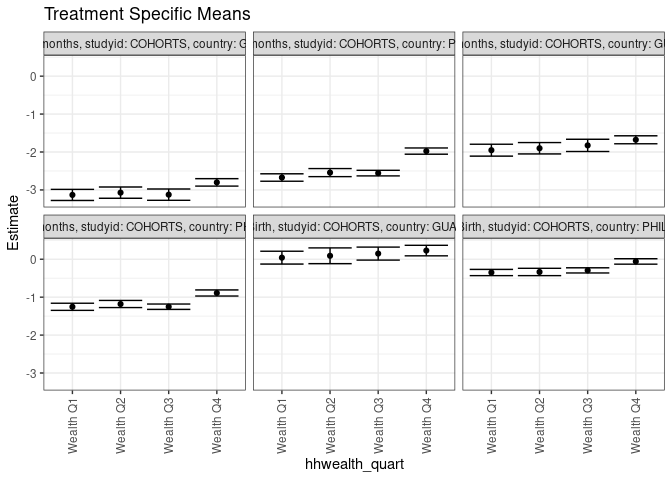

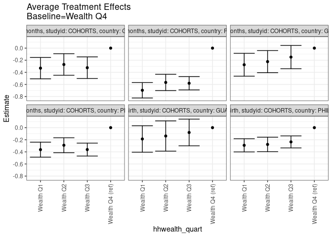

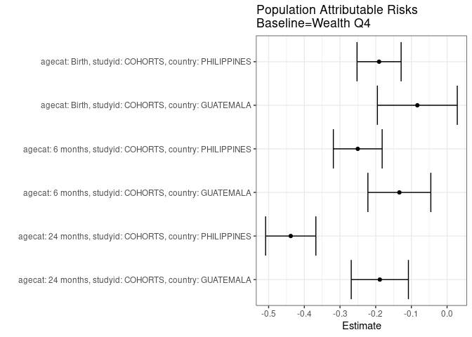

## Results Table

### Parameter: TSM

| agecat | studyid | country | intervention_level | baseline_level | estimate | ci_lower | ci_upper |
| --- | --- | --- | --- | --- | --- | --- | --- |
| Birth | COHORTS | GUATEMALA | Wealth Q4 | NA | 0.2285666 | 0.0898567 | 0.3672764 |
| Birth | COHORTS | GUATEMALA | Wealth Q1 | NA | 0.0414650 | -0.1277325 | 0.2106624 |
| Birth | COHORTS | GUATEMALA | Wealth Q2 | NA | 0.0906211 | -0.1174167 | 0.2986590 |
| Birth | COHORTS | GUATEMALA | Wealth Q3 | NA | 0.1487317 | -0.0226652 | 0.3201286 |
| Birth | COHORTS | PHILIPPINES | Wealth Q4 | NA | -0.0586342 | -0.1302466 | 0.0129782 |
| Birth | COHORTS | PHILIPPINES | Wealth Q1 | NA | -0.3503930 | -0.4322723 | -0.2685138 |
| Birth | COHORTS | PHILIPPINES | Wealth Q2 | NA | -0.3358364 | -0.4322314 | -0.2394414 |
| Birth | COHORTS | PHILIPPINES | Wealth Q3 | NA | -0.2941853 | -0.3624814 | -0.2258892 |
| 6 months | COHORTS | GUATEMALA | Wealth Q4 | NA | -1.6775811 | -1.7826026 | -1.5725596 |
| 6 months | COHORTS | GUATEMALA | Wealth Q1 | NA | -1.9522286 | -2.1091839 | -1.7952732 |
| 6 months | COHORTS | GUATEMALA | Wealth Q2 | NA | -1.9009231 | -2.0507620 | -1.7510841 |
| 6 months | COHORTS | GUATEMALA | Wealth Q3 | NA | -1.8257870 | -1.9870835 | -1.6644906 |
| 6 months | COHORTS | PHILIPPINES | Wealth Q4 | NA | -0.8903096 | -0.9707503 | -0.8098688 |
| 6 months | COHORTS | PHILIPPINES | Wealth Q1 | NA | -1.2539123 | -1.3480338 | -1.1597908 |
| 6 months | COHORTS | PHILIPPINES | Wealth Q2 | NA | -1.1810309 | -1.2750353 | -1.0870265 |
| 6 months | COHORTS | PHILIPPINES | Wealth Q3 | NA | -1.2523516 | -1.3227651 | -1.1819382 |
| 24 months | COHORTS | GUATEMALA | Wealth Q4 | NA | -2.8009453 | -2.8989963 | -2.7028942 |
| 24 months | COHORTS | GUATEMALA | Wealth Q1 | NA | -3.1316832 | -3.2780459 | -2.9853204 |
| 24 months | COHORTS | GUATEMALA | Wealth Q2 | NA | -3.0713679 | -3.2200696 | -2.9226662 |
| 24 months | COHORTS | GUATEMALA | Wealth Q3 | NA | -3.1244749 | -3.2733246 | -2.9756252 |
| 24 months | COHORTS | PHILIPPINES | Wealth Q4 | NA | -1.9760610 | -2.0579680 | -1.8941541 |
| 24 months | COHORTS | PHILIPPINES | Wealth Q1 | NA | -2.6726380 | -2.7702915 | -2.5749846 |
| 24 months | COHORTS | PHILIPPINES | Wealth Q2 | NA | -2.5430496 | -2.6497942 | -2.4363051 |
| 24 months | COHORTS | PHILIPPINES | Wealth Q3 | NA | -2.5566272 | -2.6302221 | -2.4830324 |

### Parameter: E(Y)

| agecat | studyid | country | intervention_level | baseline_level | estimate | ci_lower | ci_upper |
| --- | --- | --- | --- | --- | --- | --- | --- |
| Birth | COHORTS | GUATEMALA | NA | NA | 0.1452941 | 0.0610109 | 0.2295774 |
| Birth | COHORTS | PHILIPPINES | NA | NA | -0.2491505 | -0.2881717 | -0.2101294 |
| 6 months | COHORTS | GUATEMALA | NA | NA | -1.8112324 | -1.8807284 | -1.7417365 |
| 6 months | COHORTS | PHILIPPINES | NA | NA | -1.1405724 | -1.1824954 | -1.0986493 |
| 24 months | COHORTS | GUATEMALA | NA | NA | -2.9893430 | -3.0546993 | -2.9239867 |
| 24 months | COHORTS | PHILIPPINES | NA | NA | -2.4141145 | -2.4590818 | -2.3691473 |

### Parameter: ATE

| agecat | studyid | country | intervention_level | baseline_level | estimate | ci_lower | ci_upper |
| --- | --- | --- | --- | --- | --- | --- | --- |
| Birth | COHORTS | GUATEMALA | Wealth Q4 | Wealth Q4 | 0.0000000 | 0.0000000 | 0.0000000 |
| Birth | COHORTS | GUATEMALA | Wealth Q1 | Wealth Q4 | -0.1871016 | -0.4058896 | 0.0316864 |
| Birth | COHORTS | GUATEMALA | Wealth Q2 | Wealth Q4 | -0.1379454 | -0.3879858 | 0.1120949 |
| Birth | COHORTS | GUATEMALA | Wealth Q3 | Wealth Q4 | -0.0798348 | -0.3003282 | 0.1406585 |
| Birth | COHORTS | PHILIPPINES | Wealth Q4 | Wealth Q4 | 0.0000000 | 0.0000000 | 0.0000000 |
| Birth | COHORTS | PHILIPPINES | Wealth Q1 | Wealth Q4 | -0.2917588 | -0.4005363 | -0.1829813 |
| Birth | COHORTS | PHILIPPINES | Wealth Q2 | Wealth Q4 | -0.2772022 | -0.3972869 | -0.1571175 |
| Birth | COHORTS | PHILIPPINES | Wealth Q3 | Wealth Q4 | -0.2355511 | -0.3345092 | -0.1365931 |
| 6 months | COHORTS | GUATEMALA | Wealth Q4 | Wealth Q4 | 0.0000000 | 0.0000000 | 0.0000000 |
| 6 months | COHORTS | GUATEMALA | Wealth Q1 | Wealth Q4 | -0.2746475 | -0.4634979 | -0.0857970 |
| 6 months | COHORTS | GUATEMALA | Wealth Q2 | Wealth Q4 | -0.2233420 | -0.4063207 | -0.0403632 |
| 6 months | COHORTS | GUATEMALA | Wealth Q3 | Wealth Q4 | -0.1482059 | -0.3406795 | 0.0442676 |
| 6 months | COHORTS | PHILIPPINES | Wealth Q4 | Wealth Q4 | 0.0000000 | 0.0000000 | 0.0000000 |
| 6 months | COHORTS | PHILIPPINES | Wealth Q1 | Wealth Q4 | -0.3636027 | -0.4874154 | -0.2397901 |
| 6 months | COHORTS | PHILIPPINES | Wealth Q2 | Wealth Q4 | -0.2907214 | -0.4144450 | -0.1669977 |
| 6 months | COHORTS | PHILIPPINES | Wealth Q3 | Wealth Q4 | -0.3620421 | -0.4689475 | -0.2551367 |
| 24 months | COHORTS | GUATEMALA | Wealth Q4 | Wealth Q4 | 0.0000000 | 0.0000000 | 0.0000000 |
| 24 months | COHORTS | GUATEMALA | Wealth Q1 | Wealth Q4 | -0.3307379 | -0.5069085 | -0.1545673 |
| 24 months | COHORTS | GUATEMALA | Wealth Q2 | Wealth Q4 | -0.2704227 | -0.4485411 | -0.0923042 |
| 24 months | COHORTS | GUATEMALA | Wealth Q3 | Wealth Q4 | -0.3235296 | -0.5017717 | -0.1452875 |
| 24 months | COHORTS | PHILIPPINES | Wealth Q4 | Wealth Q4 | 0.0000000 | 0.0000000 | 0.0000000 |
| 24 months | COHORTS | PHILIPPINES | Wealth Q1 | Wealth Q4 | -0.6965770 | -0.8240327 | -0.5691213 |
| 24 months | COHORTS | PHILIPPINES | Wealth Q2 | Wealth Q4 | -0.5669886 | -0.7015365 | -0.4324407 |
| 24 months | COHORTS | PHILIPPINES | Wealth Q3 | Wealth Q4 | -0.5805662 | -0.6906795 | -0.4704528 |

### Parameter: PAR

| agecat | studyid | country | intervention_level | baseline_level | estimate | ci_lower | ci_upper |
| --- | --- | --- | --- | --- | --- | --- | --- |
| Birth | COHORTS | GUATEMALA | Wealth Q4 | NA | -0.0832724 | -0.1951957 | 0.0286509 |
| Birth | COHORTS | PHILIPPINES | Wealth Q4 | NA | -0.1905163 | -0.2523107 | -0.1287220 |
| 6 months | COHORTS | GUATEMALA | Wealth Q4 | NA | -0.1336513 | -0.2218265 | -0.0454761 |
| 6 months | COHORTS | PHILIPPINES | Wealth Q4 | NA | -0.2502628 | -0.3186550 | -0.1818707 |
| 24 months | COHORTS | GUATEMALA | Wealth Q4 | NA | -0.1883977 | -0.2685050 | -0.1082904 |
| 24 months | COHORTS | PHILIPPINES | Wealth Q4 | NA | -0.4380535 | -0.5084470 | -0.3676600 |